# Cases going up

June 17, 2020

This entry will focus on states where the coronavirus is increasing and where the levels are getting up into the ‘widespread’ epidemic level. Previous entries: https://eeholmes.github.io/CoV19/Updates.html

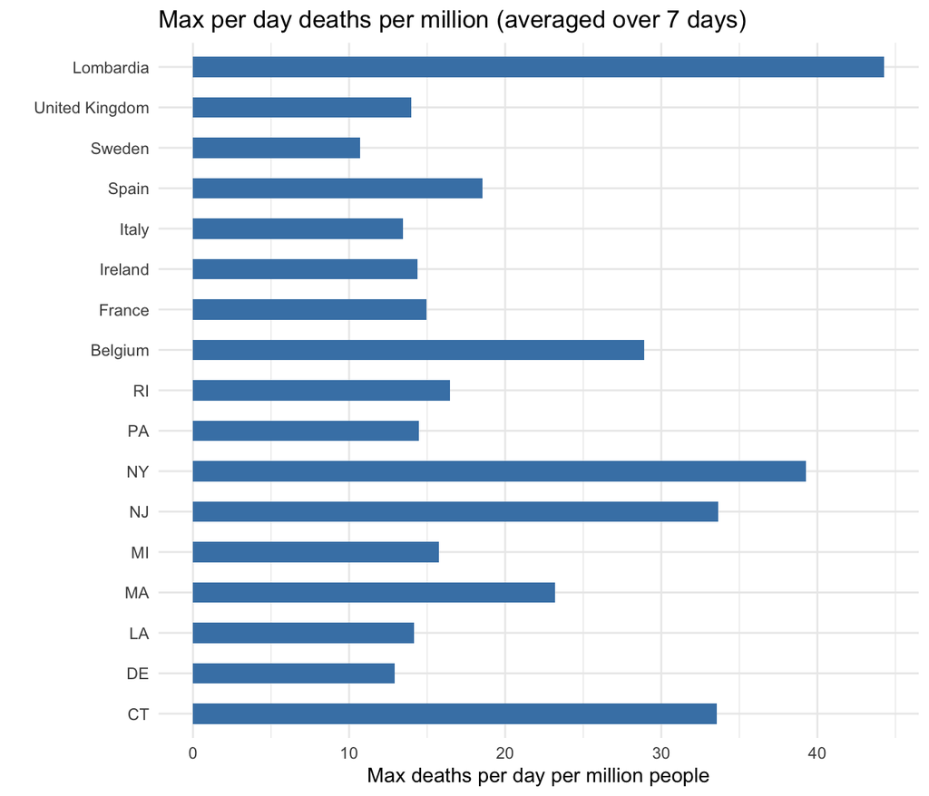

However the East Coast epidemics are on the downswing. Their epidemic trajectories followed that of most European countries, which had an effective lockdown followed by effective post-lockdown control. This bar graph shows the average new cases per day in March and currently versus what they were at the peak of the epidemics.

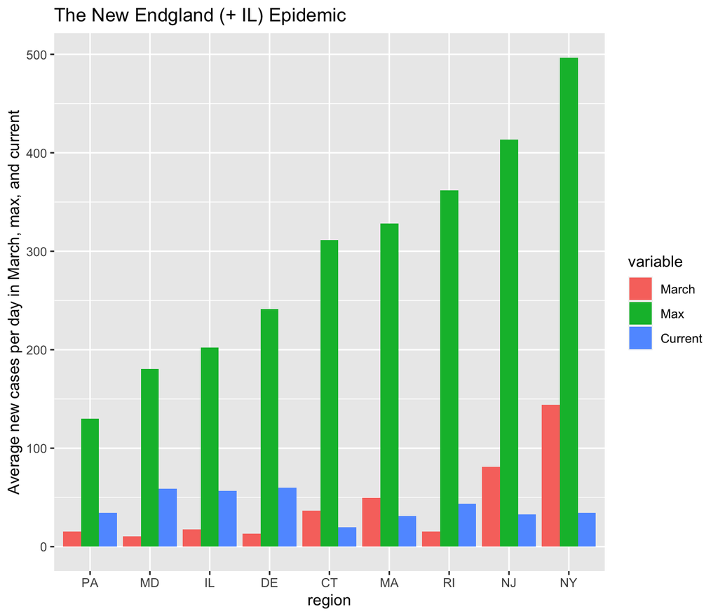

Here are the full epidemic trajectories.

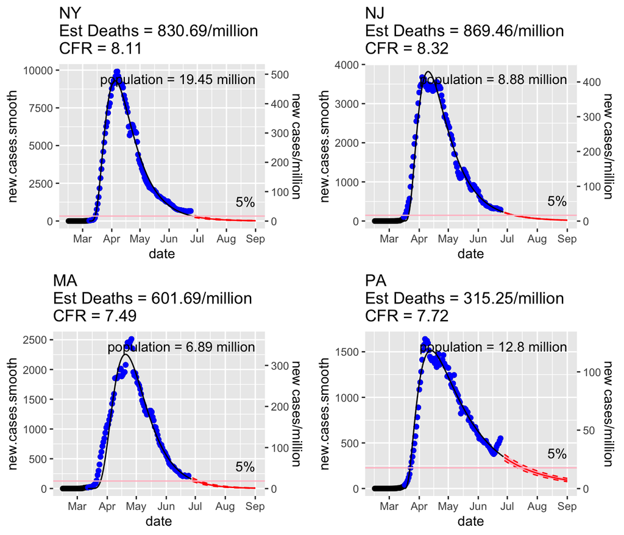

## Epidemics starting in the rest of the US

Many US states avoided the spring peak and cases stayed fairly low (per capita), but now cases are going up. It was well-known that this is the pattern we would see; lots of discussion that we’d see this pattern and locking down in other states was in part to avoid all the states experiencing an epidemic at the same time. Obviously, another goal was to get us into summer, out of peak respiratory illness season, and hopefully other states wouldn’t suffer the fate of the east coast states. It looks like that’s not happening. The disease is spreading in focus points (like factories and institutions) and then community spread is occurring as people are not social-distancing (including importantly mask-wearing) enough to stop community spread.

Right now in Arizona, Arkansas, and Alabama, the per capita new cases is getting into the +150 per million zone where health care system are hard hit and control of the epidemic is lost (meaning community spread is so pervasive that mitigations don’t stop a rapid rise in cases). The Carolinas and Utah are going up fast and are now above 100 per million per day. This plot shows the states (in red) where the current new cases per day are above 100 and cases are going up fast. For comparison, the peak new cases per day in three hard hit east coast states are shown in blue.

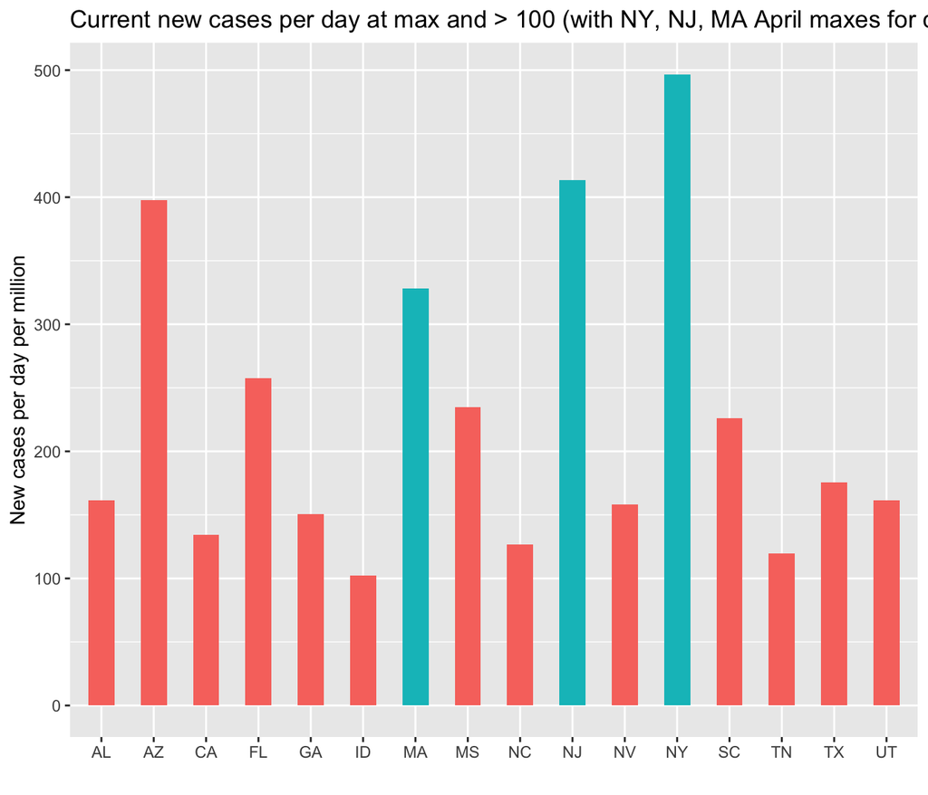

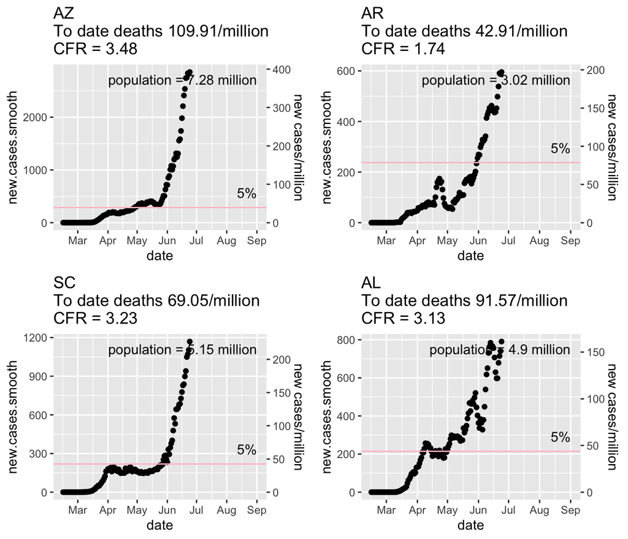

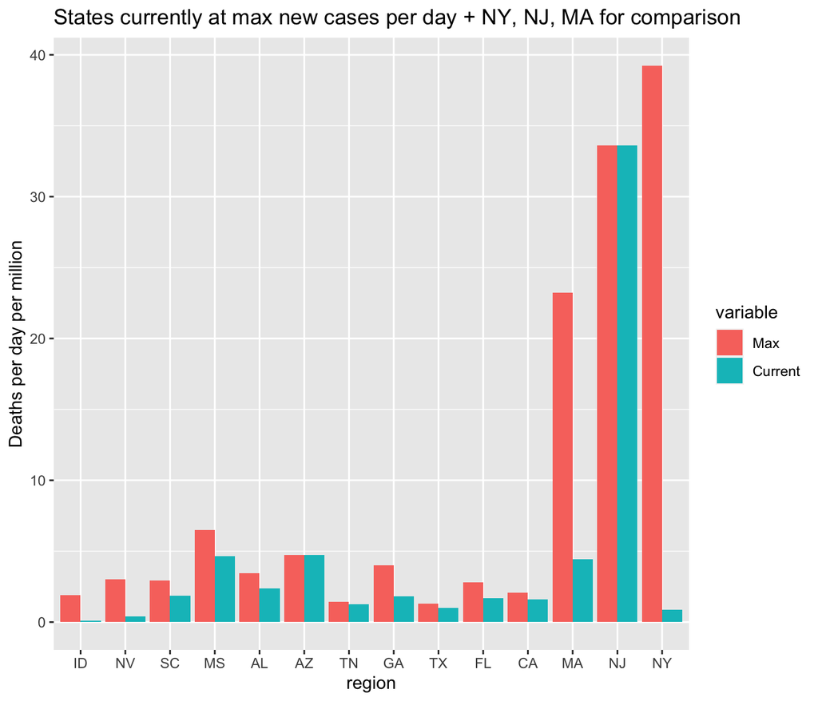

Looking at the current deaths per day and comparing to NY, NJ and MA gives you an idea of what to expect in the next few weeks for the states currently experiencing a rise in cases. If you look at the plot, things probably feel “ok”. Cases are rising but deaths per day are lower. That’s is about to change. My back of the envelope is we’ll see 10-fold increases in the death rate in the next 30 days. Once the states peak, it’s about 8 weeks to get back down if they successfully stop the spread. Another lockdown seems unlikely so it may be that we see the Swedish-type of epidemic, where a huge peak is avoided but the disease takes hold and we see steady high new cases and deaths for many months.

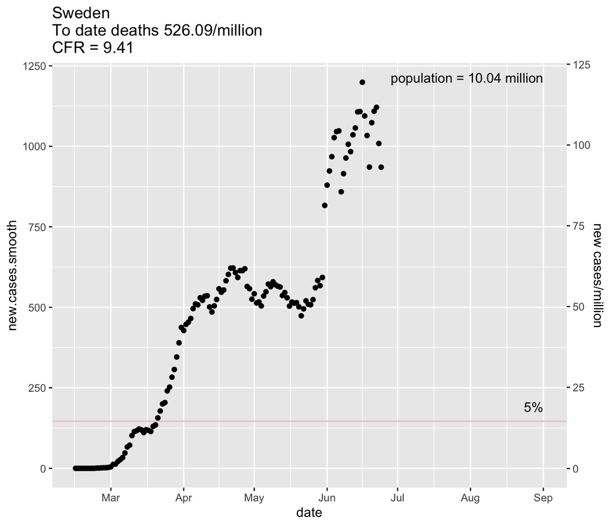

## Other states currently at peak new cases per day

The previous plots highlighted those states that are getting into the levels where their health systems are starting to get strained. New cases per day per million over 150 is going to start stressing the system. But there are a number of other states that are seeing the highest number of new cases per day that they have ever seen. It was definitely known that cases would go up as states loosened restrictions and people began moving around.

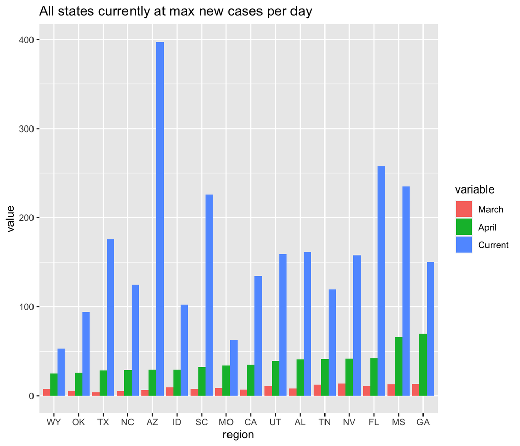

## Turning this around

The goal now for public officials will be to turn this around. I am not hearing talk about more lockdowns. Epidemiologists now have a fairly good idea of how to stop spread. It turns out that fairly low tech methods work, but the question is whether enough people will adopt these practices.

### Masks

So, if you are not following the public health news, mask definitely work. Some recent studies. Note, thanks to Corvin Russell for many of these refs.

- The case of the 2 covid-positive hairdressers in Missouri who worked on 140 customers. Both the hairdressers and customers were masked and customers were staggered (had appointments). The customers were tracked for a month. [None became infected](https://www.washingtonpost.com/business/2020/06/17/masks-salons-missouri/).
- [Science paper on masks and airborne spread](https://science.sciencemag.org/content/early/2020/06/08/science.abc6197)
- [Science paper on aerosol transmission](https://www.sciencemag.org/news/2020/04/you-may-be-able-spread-coronavirus-just-breathing-new-report-finds) Aerosol transmission means you can spread by breathing and virus ‘hangs in the air’. In this case distance and hand-washing doesn’t help so much, but masks help a lot as well as staying away from indoor spaces with many people.

An epidemiologist who is involved in the CA response and spoke to my work said that masks will be mandatory eventually (so we might as well get used to it). Currently a number of east coast states (NY, NJ, CT and MA) require masks for everyone when in a public space where distance is not possible. [Here’s a state by state summary of the rules by state](https://www.littler.com/publication-press/publication/facing-your-face-mask-duties-list-statewide-orders); some cities have stricter rules.

### Clusters and super-spreaders

- [Science article on an analysis of cluster](https://www.sciencemag.org/news/2020/05/why-do-some-covid-19-patients-infect-many-others-whereas-most-don-t-spread-virus-all) [CDC article on the same](https://wwwnc.cdc.gov/eid/article/26/9/20-2272_article?fbclid=IwAR0RSkOspMjp7emFfZJuXzHXy7pSxOhrw9LiTwd9fj1EnD88XaURLPNpaZk) It’s happening mainly indoors where many people are crowded together.
- [Another article on clusters and superspreaders](https://arstechnica.com/science/2020/06/just-10-20-of-covid-19-cases-behind-80-of-transmission-studies-suggest) Take-home is that we don’t know who will become a super-spreader but we know what kinds of events lead to super-spreading and we can stop those events and thus stop most of the super-spreader events. Basically anytime you have large groups indoors together, esp talking, singing, chanting, etc., that is the set-up for a super-spreader event.

Japan distills the risky situations to the 3 C’s: closed, crowded and close. To reduce super-spreading events and reduce your personal risk: “Avoid (1) Closed spaces with poor ventilation, (2) Crowded places, and (3) Close-contact settings, such as close-range conversations.” Going to a friends’ house for dinner? Sit outside and don’t sit right next to each other. Stay out of indoor spaces with lots of people. Head to the store in the off hours. Don’t go in if it is packed.